# Practicum_2

2024-03-17

#### Loading the necessary libraries

```r
library(tidyverse)
library(rebus)
library(RSQLite)
```

#### Bed_fact dataset

```r
bed_fact = read_csv("/Users/sharadraina/Desktop/Practicum/untitled folder/bed_fact-1.csv" , show_col_types = FALSE)

head(bed_fact)
```

```
## # A tibble: 6 × 5
##   ims_org_id  bed_id license_beds census_beds staffed_beds
##   <chr>        <dbl>        <dbl>       <dbl>        <dbl>
## 1 INS00000519      2           10           7           10
## 2 INS00000519      5          566         394          566
## 3 INS00000519     15           25          17           25
## 4 INS00000519      4           38          26           38
## 5 INS00000519      6           32          22           32
## 6 INS00000519     18          671         466          671
```

#### EDA

```r
#Checking for dimensions of the dataset.
dim(bed_fact)
```

```
## [1] 51458     5
```

```r
#Checing for NA values
sum(is.na(bed_fact))
```

```
## [1] 0
```

```r
#Checking for duplicate values
sum(duplicated(bed_fact))
```

```
## [1] 0
```

```r
#Checking distribution for bed id's
 sort(table(bed_fact$bed_id) , decreasing = TRUE)
```

```
##
##    18     8     5     4    16    12     6     2    14    15    10     1     3
## 22192 14982  6081  3342  1170  1009   762   680   492   209   188   109    75
##     9    19     7    13    20    11    17
##    55    44    20    16    15    14     3
```

##### The data set consists of 51458 rows and 5 columns. The number of NA and duplicate values are zero. The table function reveals that the maximum number of beds belong to bed_id 18 followed by 8. This can be attributed to important description the bed is being used for like surgery or ICU etc.

```r
#Checking summary statistics of the dataset.

summary(bed_fact)
```

```
##   ims_org_id            bed_id       license_beds     census_beds
##  Length:51458       Min.   : 1.00   Min.   :   1.0   Min.   :   0.00
##  Class :character   1st Qu.: 8.00   1st Qu.:  41.0   1st Qu.:  29.00
##  Mode  :character   Median : 8.00   Median :  86.0   Median :  66.00
##                     Mean   :11.94   Mean   : 104.2   Mean   :  81.27
##                     3rd Qu.:18.00   3rd Qu.: 127.8   3rd Qu.: 110.00
##                     Max.   :20.00   Max.   :2007.0   Max.   :1505.00
##   staffed_beds
##  Min.   :   0.00
##  1st Qu.:  39.00
##  Median :  83.00
##  Mean   :  99.17
##  3rd Qu.: 124.00
##  Max.   :1527.00
```

##### The ims_org_id column is a foreign key which represents the unique id’s of different hospitals totalling 51458 in number. This number may reflect duplicate values as well. The bed_id column is a foreign key here and its max value represents that we have 20 different types of bed like ICU , Surgery etc. The rest of the columns represent total number of beds for each of the 3 bed types. From the above figures, it can be said that license_beds are highest in number followed by staffed_beds and census_beds.

#### Plotting each type of bed

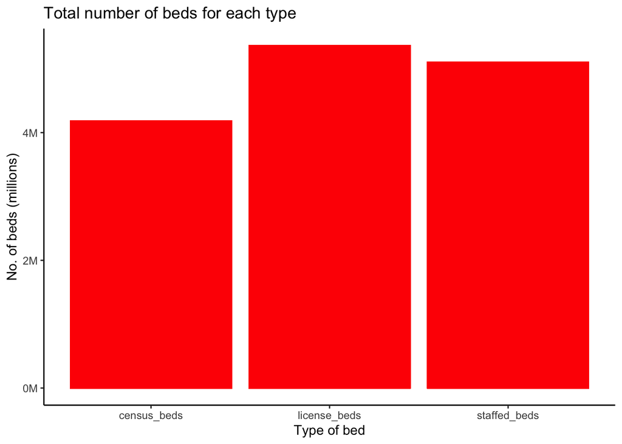

```r
beds =  bed_fact %>%

  pivot_longer(cols = c("license_beds","census_beds","staffed_beds") , names_to = "Type of bed" , values_to = "No. of beds")


beds %>%

  ggplot(aes(`Type of bed` , `No. of beds` / 1000000 )) +

  geom_bar(stat = "identity", color = "red") +

  scale_y_continuous(labels = function(x) paste0(x , "M")) +

  labs(title = "Total number of beds for each type" , y = "No. of beds (millions)") +

  theme_classic()
```

#### Bed_type dataset

```r
bed_type = read_csv("/Users/sharadraina/Desktop/Practicum/untitled folder/bed_fact-1.csv" , show_col_types = FALSE)

head(bed_type)
```

```
## # A tibble: 6 × 5
##   ims_org_id  bed_id license_beds census_beds staffed_beds
##   <chr>        <dbl>        <dbl>       <dbl>        <dbl>
## 1 INS00000519      2           10           7           10
## 2 INS00000519      5          566         394          566
## 3 INS00000519     15           25          17           25
## 4 INS00000519      4           38          26           38
## 5 INS00000519      6           32          22           32
## 6 INS00000519     18          671         466          671
```

#### EDA

```r
#Checking for dimensions of the dataset.
dim(bed_type)
```

```
## [1] 51458     5
```

```r
#Checking for any missing values.
sum(is.na(bed_type))
```

```
## [1] 0
```

```r
#Checking for any duplicate records
sum(duplicated(bed_type))
```

```
## [1] 0
```

```r
#Checking summary statistics for the dataset.

summary(bed_type)
```

```
##   ims_org_id            bed_id       license_beds     census_beds
##  Length:51458       Min.   : 1.00   Min.   :   1.0   Min.   :   0.00
##  Class :character   1st Qu.: 8.00   1st Qu.:  41.0   1st Qu.:  29.00
##  Mode  :character   Median : 8.00   Median :  86.0   Median :  66.00
##                     Mean   :11.94   Mean   : 104.2   Mean   :  81.27
##                     3rd Qu.:18.00   3rd Qu.: 127.8   3rd Qu.: 110.00
##                     Max.   :20.00   Max.   :2007.0   Max.   :1505.00
##   staffed_beds
##  Min.   :   0.00
##  1st Qu.:  39.00
##  Median :  83.00
##  Mean   :  99.17
##  3rd Qu.: 124.00
##  Max.   :1527.00
```

#### Bussiness dataset

```r
bussiness = read_csv("/Users/sharadraina/Desktop/Practicum/untitled folder/business-1.csv")
head(bussiness)
```

```
## # A tibble: 6 × 6
##   ims_org_id  business_name    ttl_license_beds ttl_census_beds ttl_staffed_beds
##   <chr>       <chr>                       <dbl>           <dbl>            <dbl>
## 1 INS00077200 140 Prescott St…              126             122              126
## 2 INS00000594 366th Medical G…               10               4               10
## 3 INS00039181 7 Hills Pediatr…               83              75               83
## 4 INS00011388 92 Brickroad Op…               49              46               49
## 5 INS00000593 96th Medical Gr…               53              22               53
## 6 INS00036273 A and C Healthc…              130             122              130
## # ℹ 1 more variable: bed_cluster_id <dbl>
```

#### EDA

```r
#Checking for dimensions of the dataset.
dim(bussiness)
```

```
## [1] 22202     6
```

```r
#Checking for NA values
sum(is.na(bussiness))
```

```
## [1] 0
```

```r
#Checking for duplicate records
sum(duplicated(bussiness))
```

```
## [1] 0
```

```r
# Checking for summary statistics.

summary(bussiness)
```

```
##   ims_org_id        business_name      ttl_license_beds ttl_census_beds
##  Length:22202       Length:22202       Min.   :   2.0   Min.   :   0.00
##  Class :character   Class :character   1st Qu.:  59.0   1st Qu.:  44.00
##  Mode  :character   Mode  :character   Median :  99.0   Median :  80.00
##                                        Mean   : 120.8   Mean   :  94.19
##                                        3rd Qu.: 140.0   3rd Qu.: 117.00
##                                        Max.   :2007.0   Max.   :1505.00
##  ttl_staffed_beds bed_cluster_id
##  Min.   :   0.0   Min.   :1.000
##  1st Qu.:  56.0   1st Qu.:1.000
##  Median :  98.0   Median :1.000
##  Mean   : 114.9   Mean   :1.455
##  3rd Qu.: 136.0   3rd Qu.:2.000
##  Max.   :1527.0   Max.   :9.000
```

##### The ims_org_id column acts as a primary key that records names of various hospitals that are 22202 in number. The rest columns represent the total number of beds each hospital has for the 3 bed types.

#### Question 1 Identifying dimension variables

```r
#Identifying dimension and fact variable from bed_type dataframe.
head(bed_type)
```

```
## # A tibble: 6 × 5
##   ims_org_id  bed_id license_beds census_beds staffed_beds
##   <chr>        <dbl>        <dbl>       <dbl>        <dbl>
## 1 INS00000519      2           10           7           10
## 2 INS00000519      5          566         394          566
## 3 INS00000519     15           25          17           25
## 4 INS00000519      4           38          26           38
## 5 INS00000519      6           32          22           32
## 6 INS00000519     18          671         466          671
```

```r
#Identifying dimension and fact variable from bussiness dataframe.

head(bussiness)
```

```
## # A tibble: 6 × 6
##   ims_org_id  business_name    ttl_license_beds ttl_census_beds ttl_staffed_beds
##   <chr>       <chr>                       <dbl>           <dbl>            <dbl>
## 1 INS00077200 140 Prescott St…              126             122              126
## 2 INS00000594 366th Medical G…               10               4               10
## 3 INS00039181 7 Hills Pediatr…               83              75               83
## 4 INS00011388 92 Brickroad Op…               49              46               49
## 5 INS00000593 96th Medical Gr…               53              22               53
## 6 INS00036273 A and C Healthc…              130             122              130
## # ℹ 1 more variable: bed_cluster_id <dbl>
```

##### This dataset has 3 dimension variables which are ims_org_id, business_name and bed_cluster_id. These columns represents attributes and provide qualitative information for the variable they store hence they are acting as dimension variables. The columns ttl_license_beds, ttl_census_beds and ttl_staffed_beds represent total number of beds that each hospital has and thus represents a quantitative measurement which can provide some bussiness analysis.

#### Question 2 Identifying fact variables

```r
head(bed_fact)
```

```
## # A tibble: 6 × 5
##   ims_org_id  bed_id license_beds census_beds staffed_beds
##   <chr>        <dbl>        <dbl>       <dbl>        <dbl>
## 1 INS00000519      2           10           7           10
## 2 INS00000519      5          566         394          566
## 3 INS00000519     15           25          17           25
## 4 INS00000519      4           38          26           38
## 5 INS00000519      6           32          22           32
## 6 INS00000519     18          671         466          671
```

##### In this dataset there are 2 dimension variables which are ims_org_id and bed_id as these are categorical data representing attributes of hospital names as well as bed description. These variables dont provide any quantitative value which can be used to analyse data. The remaining 3 columns in the dataset are fact variables as they are continuous in nature and represent quantitative information which can be aggregated or compared or analysed to derive some bussiness metrics.

#### Creating my connection “dbconnection” to the database

```r
dbconnection = dbConnect(SQLite() , "/Users/sharadraina/Desktop/Practicum/untitled folder/beddb.db")
```

#### Checking the tables in my database

```r
dbListTables(dbconnection)
```

```
## [1] "bedfact"   "bedtype"   "bussiness"
```

#### 3a. Analysis for Leadership

```r
#Top 10 hospitals ordered by license beds after performing inner join on bed fact and bussiness table.


query =  "SELECT business_name, SUM(CAST(license_beds AS INT)) AS [Total License Beds]
          FROM bedfact
          JOIN bussiness ON bedfact.ims_org_id = bussiness.ims_org_id
          WHERE bed_id = 4 OR bed_id = 15
          GROUP BY business_name
          ORDER BY [Total License Beds] DESC
          LIMIT 10;"

License_Beds =  dbGetQuery(dbconnection , query)

License_Beds
```

```
##                                          business_name Total License Beds
## 1                           Phoenix Childrens Hospital                247
## 2                University of Maryland Medical Center                220
## 3                        UC Health University Hospital                218
## 4                               Wesley Medical Center                 214
## 5                                Vidant Medical Center                204
## 6            Rady Childrens Hospital and Health Center                200
## 7                   Dallas County Hospital Association                195
## 8  Saint Lukes Episcopal Hospital Texas Medical Center                178
## 9                               The Methodist Hospital                170
## 10                           Emory University Hospital                169
```

```r
#Top 10 hospitals ordered by census beds after performing inner join on bed fact and bussiness table.


query =  "SELECT business_name, SUM(CAST(census_beds AS INT)) AS [Total Census Beds]
          FROM bedfact
          JOIN bussiness ON bedfact.ims_org_id = bussiness.ims_org_id
          WHERE bed_id = 4 OR bed_id = 15
          GROUP BY business_name
          ORDER BY [Total Census Beds] DESC
          LIMIT 10;"

Census_Beds =  dbGetQuery(dbconnection , query)

Census_Beds
```

```
##                                                              business_name
## 1                             Shands Hospital at the University of Florida
## 2                                       Dallas County Hospital Association
## 3                                         Mercy Medical Center Saint Louis
## 4  Los Angeles County University of Southern California Healthcare Network
## 5                                                   The Methodist Hospital
## 6                          University of Minnesota Medical Center Fairview
## 7                                    University of Maryland Medical Center
## 8                                              Brigham and Womens Hospital
## 9                                                    Vidant Medical Center
## 10       Ronald Reagan University of California Los Angeles Medical Center
##    Total Census Beds
## 1                167
## 2                145
## 3                142
## 4                139
## 5                138
## 6                129
## 7                127
## 8                124
## 9                123
## 10               122
```

```r
#Top 10 hospitals ordered by staffed beds after performing inner join on bed fact and bussiness table.


query =  "SELECT business_name, SUM(CAST(staffed_beds AS INT)) AS [Total Staffed Beds]
          FROM bedfact
          JOIN bussiness ON bedfact.ims_org_id = bussiness.ims_org_id
          WHERE bed_id = 4 OR bed_id = 15
          GROUP BY business_name
          ORDER BY [Total Staffed Beds] DESC
          LIMIT 10;"

Staffed_Beds =  dbGetQuery(dbconnection , query)

Staffed_Beds
```

```
##                                   business_name Total Staffed Beds
## 1                         Vidant Medical Center                203
## 2     Rady Childrens Hospital and Health Center                200
## 3         University of Maryland Medical Center                171
## 4                     Emory University Hospital                169
## 5  Shands Hospital at the University of Florida                167
## 6              Mercy Medical Center Saint Louis                163
## 7                        Wesley Medical Center                 162
## 8                    Phoenix Childrens Hospital                159
## 9                       Grady Memorial Hospital                154
## 10                UC Health University Hospital                151
```

#### 4a. Drill down investigation

```r
#Query for fetching top 10 hospitals having both SICU and ICU beds
query = "SELECT  business_name , SUM(cast(license_beds as int)) [Total License Beds]

FROM    bedfact

join bussiness on bedfact.ims_org_id = bussiness.ims_org_id

join bedtype on bedtype.bed_id = bedfact.bed_id

where bedfact.bed_id in (15,4)

group by business_name

having COUNT(business_name) > 1

order by [Total License Beds] desc

limit 10 ;"


Total_License_Beds = dbGetQuery(dbconnection , query)

Total_License_Beds
```

```
##                                      business_name Total License Beds
## 1            University of Maryland Medical Center                220
## 2                    UC Health University Hospital                218
## 3     Shands Hospital at the University of Florida                167
## 4                                       MCGHealth                 155
## 5                          Grady Memorial Hospital                154
## 6                        Jackson Memorial Hospital                151
## 7  University of Minnesota Medical Center Fairview                144
## 8              University Hospital in Bexar County                144
## 9                         Carolinas Medical Center                137
## 10                         Yale New Haven Hospital                136
```

```r
#Query for fetching top 10 hospitals having both SICU and ICU beds
query = "SELECT  business_name , SUM(cast(census_beds as int)) [Total Census Beds]

FROM    bedfact

join bussiness on bedfact.ims_org_id = bussiness.ims_org_id

join bedtype on bedtype.bed_id = bedfact.bed_id

where bedfact.bed_id in (15,4)

group by business_name

having COUNT(business_name) > 1

order by [Total Census Beds] desc

limit 10 ;"


Total_Census_Beds = dbGetQuery(dbconnection , query)

Total_Census_Beds
```

```
##                                      business_name Total Census Beds
## 1     Shands Hospital at the University of Florida               167
## 2  University of Minnesota Medical Center Fairview               129
## 3            University of Maryland Medical Center               127
## 4                        Jackson Memorial Hospital               117
## 5                    UC Health University Hospital               110
## 6                         Carolinas Medical Center               106
## 7                       Cedars Sinai Health System                92
## 8              University Hospital in Bexar County                91
## 9                    Duke University Health System                91
## 10                 The Cleveland Clinic Foundation                88
```

```r
#Query for fetching top 10 hospitals having both SICU and ICU beds
query = "SELECT  business_name , SUM(cast(staffed_beds as int)) [Total Staffed Beds]

FROM    bedfact

join bussiness on bedfact.ims_org_id = bussiness.ims_org_id

join bedtype on bedtype.bed_id = bedfact.bed_id

where bedfact.bed_id in (15,4)

group by business_name

having COUNT(business_name) > 1

order by [Total Staffed Beds] desc

limit 10 ;"


Total_Staffed_Beds = dbGetQuery(dbconnection , query)

Total_Staffed_Beds
```

```
##                                      business_name Total Staffed Beds
## 1            University of Maryland Medical Center                171
## 2     Shands Hospital at the University of Florida                167
## 3                          Grady Memorial Hospital                154
## 4                    UC Health University Hospital                151
## 5  University of Minnesota Medical Center Fairview                144
## 6                         Carolinas Medical Center                137
## 7        Saint Josephs Hospital and Medical Center                134
## 8   Chattanooga Hamilton County Hospital Authority                134
## 9                        Jackson Memorial Hospital                128
## 10            Sunrise Hospital and Medical Center                 125
```